# Create KMunicate-Style Plots

The {KMunicate} package can be used to produce Kaplan-Meier plots in the style recommended following the [KMunicate study](https://bmjopen.bmj.com/content/9/9/e030215) by TP Morris *et al*. (2019).

In this vignette, we’ll see learn how to produce such a plot using the {KMunicate} package.

## Data

We will be using the `brcancer` dataset, which comes bundled with {KMunicate}:

```r
data("brcancer", package = "KMunicate")
str(brcancer)
```

```
#> Classes 'tbl_df', 'tbl' and 'data.frame':    686 obs. of  14 variables:
#>  $ id     : num  1 2 3 4 5 6 7 8 9 10 ...
#>  $ hormon : num  0 1 1 1 0 0 1 0 0 0 ...
#>  $ x1     : num  70 56 58 59 73 32 59 65 80 66 ...
#>  $ x2     : num  2 2 2 2 2 1 2 2 2 2 ...
#>  $ x3     : num  21 12 35 17 35 57 8 16 39 18 ...
#>  $ x4     : num  2 2 2 2 2 3 2 2 2 2 ...
#>  $ x5     : num  3 7 9 4 1 24 2 1 30 7 ...
#>  $ x6     : num  48 61 52 60 26 0 181 192 0 0 ...
#>  $ x7     : num  66 77 271 29 65 13 0 25 59 3 ...
#>  $ rectime: num  1814 2018 712 1807 772 ...
#>  $ censrec: num  1 1 1 1 1 1 0 0 1 0 ...
#>  $ x4a    : num  1 1 1 1 1 1 1 1 1 1 ...
#>  $ x4b    : num  0 0 0 0 0 1 0 0 0 0 ...
#>  $ x5e    : num  0.698 0.432 0.34 0.619 0.887 ...
#>  - attr(*, "label")= chr "German breast cancer data"
```

## Single-Arm Plot

We start by creating a KMunicate-style plot for all study subjects. First, we load the package:

```r
library(KMunicate)
```

Then, we fit a Kaplan-Meier curve using the `survfit` function from the {survival} package:

```r
fit <- survfit(Surv(rectime, censrec) ~ 1, data = brcancer)
fit
```

```
#> Call: survfit(formula = Surv(rectime, censrec) ~ 1, data = brcancer)
#>
#>        n events median 0.95LCL 0.95UCL
#> [1,] 686    299   1807    1587    2030
```

Then, we need to define the horizontal axis of the plot. For instance, we can define 5 equally-spaced breaks between time zero and the largest observed time:

```r
ts <- seq(0, max(brcancer$rectime), length.out = 5)
ts
```

```
#> [1]    0.00  664.75 1329.50 1994.25 2659.00
```

Finally, we can pass `fit` and `ts` to the `KMunicate()` function to simply obtain a plot:

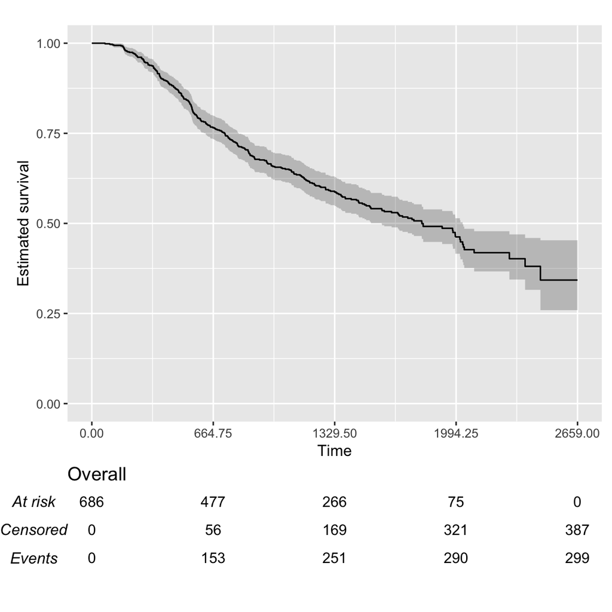

```r
KMunicate(fit = fit, time_scale = ts)
```

## Multiple-Arms Plot

A multiple-arms plot will be automatically produced if the `survfit` object has covariates in it. For instance, if we fit the Kaplan-Meier estimator by treatment arm:

```r
fit2 <- survfit(Surv(rectime, censrec) ~ hormon, data = brcancer)
fit2
```

```
#> Call: survfit(formula = Surv(rectime, censrec) ~ hormon, data = brcancer)
#>
#>            n events median 0.95LCL 0.95UCL
#> hormon=0 440    205   1528    1296    1814
#> hormon=1 246     94   2018    1918      NA
```

We will be using the same time scale as before (`ts`), and the call to `KMunicate()` is analogous:

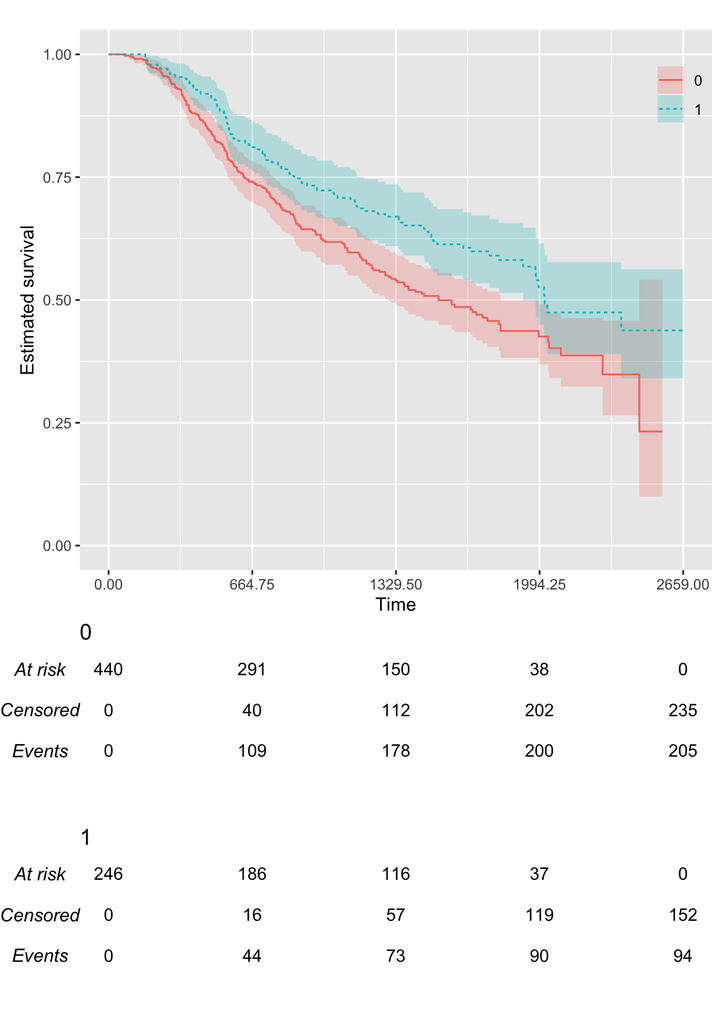

```r
KMunicate(fit = fit2, time_scale = ts)
```

## Customisation

The `KMunicate()` function contains a few options to customise the produced plot. First, we can pass a `ggplot2` theme to the `.theme` argument:

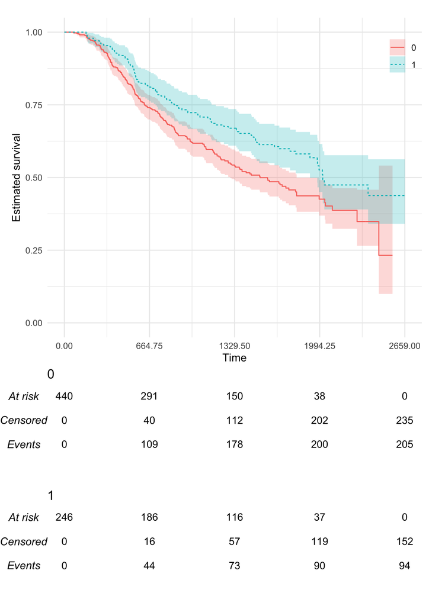

```r
KMunicate(fit = fit2, time_scale = ts, .theme = ggplot2::theme_minimal())
```

We can also pass custom colour (and fill) scales:

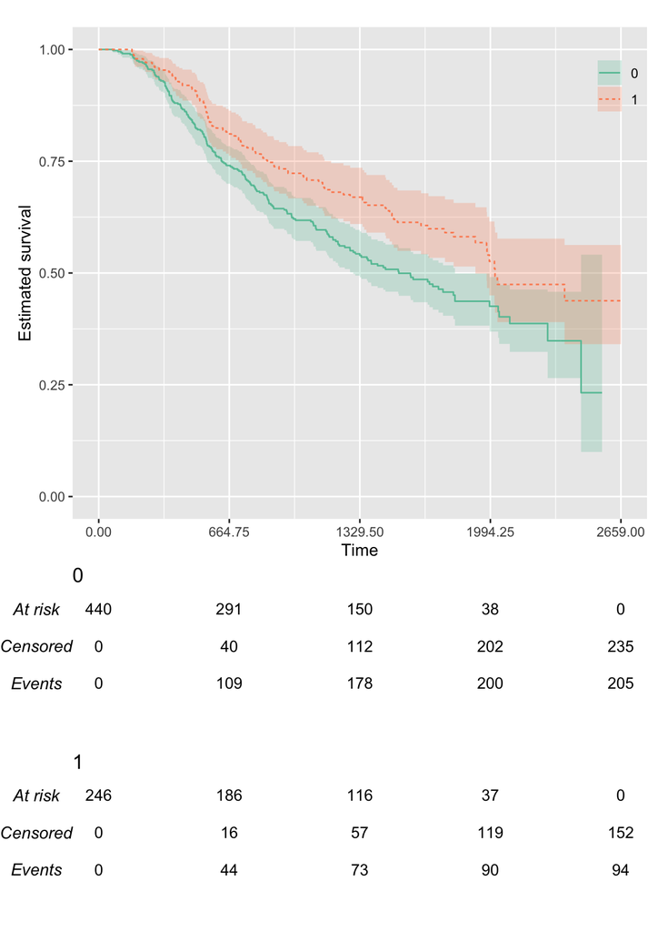

```r
KMunicate(
  fit = fit2,
  time_scale = ts,
  .color_scale = ggplot2::scale_color_brewer(type = "qual", palette = "Set2"),
  .fill_scale = ggplot2::scale_fill_brewer(type = "qual", palette = "Set2")
)
```

We can customise the transparency of the point-wise confidence intervals via the `.alpha` argument:

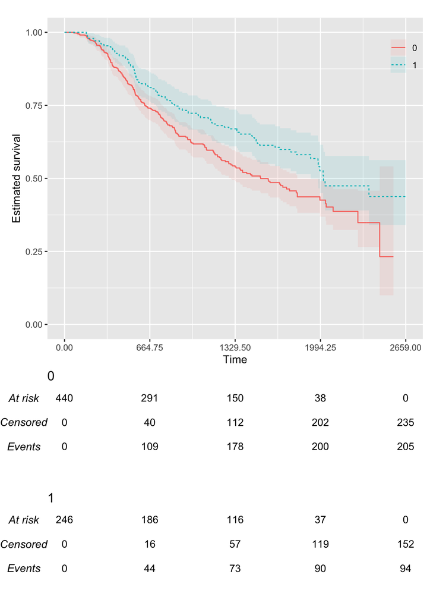

```r
KMunicate(fit = fit2, time_scale = ts, .alpha = 0.1)
```

We can customise the label of the horizontal axis:

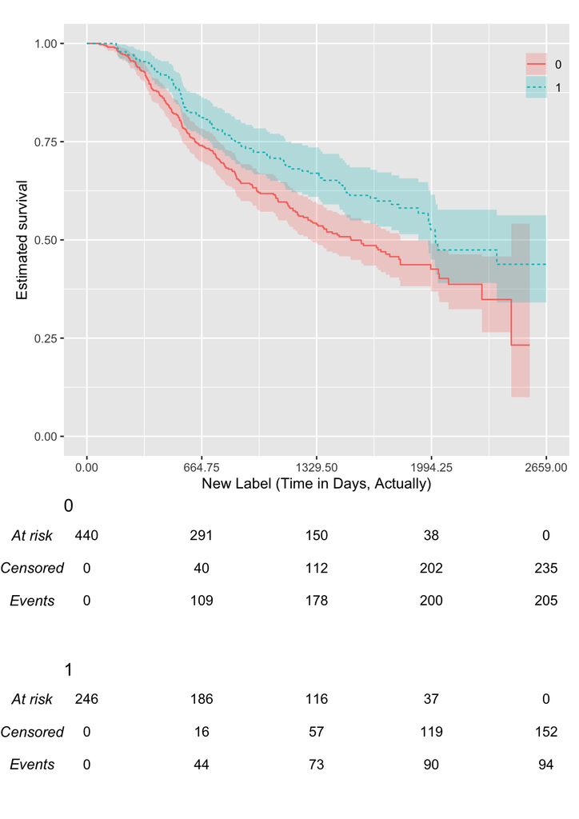

```r
KMunicate(fit = fit2, time_scale = ts, .xlab = "New Label (Time in Days, Actually)")
```

We can customise the relative size of risk tables and plots, although the default *should* generally work fine for most scenarios:

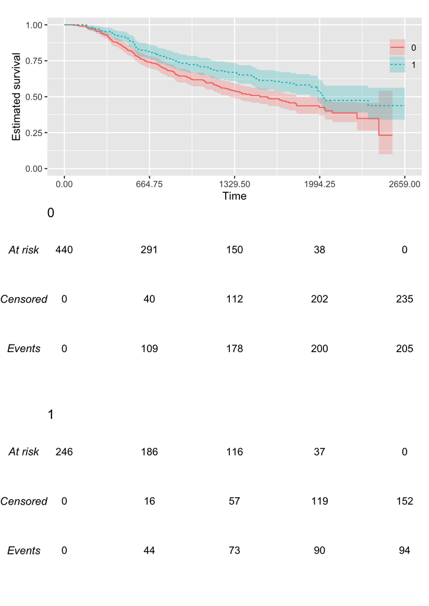

```r
KMunicate(fit = fit2, time_scale = ts, .rel_heights = c(1, 1, 1))
```

# Custom Fonts

Assuming you have set up your computer and R session to support custom fonts (e.g. using a [`ragg`](https://CRAN.R-project.org/package=ragg) graphics device), you can produce plots with custom fonts via the `.ff` argument of the `KMunicate()` function. Examples of using `ragg` can be found [here](https://www.tidyverse.org/blog/2021/02/modern-text-features/).

# A *Better* Plot

We can combine all the above to obtain an (arguably) much better plot:

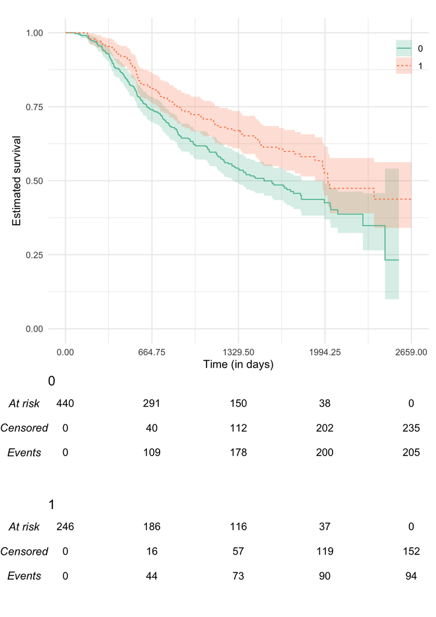

```r
KMunicate(
  fit = fit2,
  time_scale = ts,
  .theme = ggplot2::theme_minimal(),
  .xlab = "Time (in days)",
  .color_scale = ggplot2::scale_color_brewer(type = "qual", palette = "Set2"),
  .fill_scale = ggplot2::scale_fill_brewer(type = "qual", palette = "Set2")
)
```

# Further Customisation Options

As of version 0.2.0, {KMunicate} provide additional arguments to customise the final plot.

You can customise the size of each Kaplan-Meier curve via the `.size` argument:

```r
KMunicate(
  fit = fit2,
  time_scale = ts,
  .size = 2
)
```

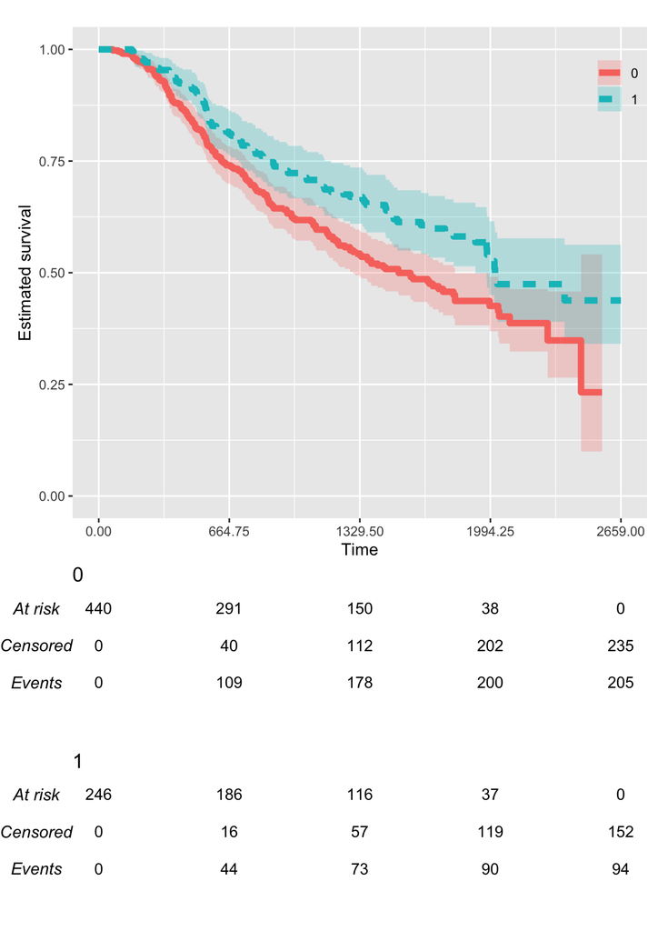

You can customise the linetype scale via the `.linetype_scale` argument:

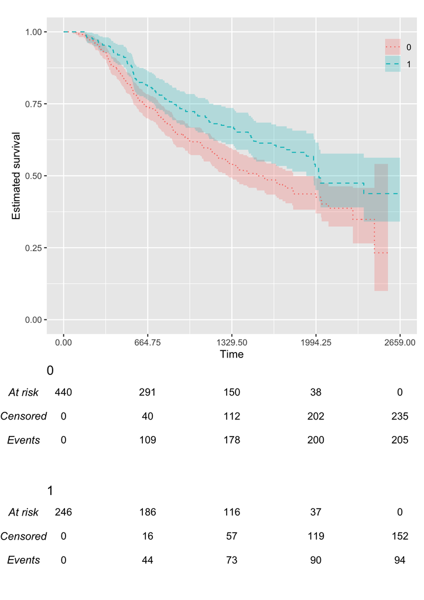

```r
KMunicate(
  fit = fit2,
  time_scale = ts,
  .linetype_scale = ggplot2::scale_linetype_manual(values = c("dotted", "dashed"))
)
```

You can customise the location of the legend via the `.legend_position` argument, or you can even suppress it fully:

```r
KMunicate(
  fit = fit2,
  time_scale = ts,
  .reverse = TRUE,
  .legend_position = c(0, 1)
)
```

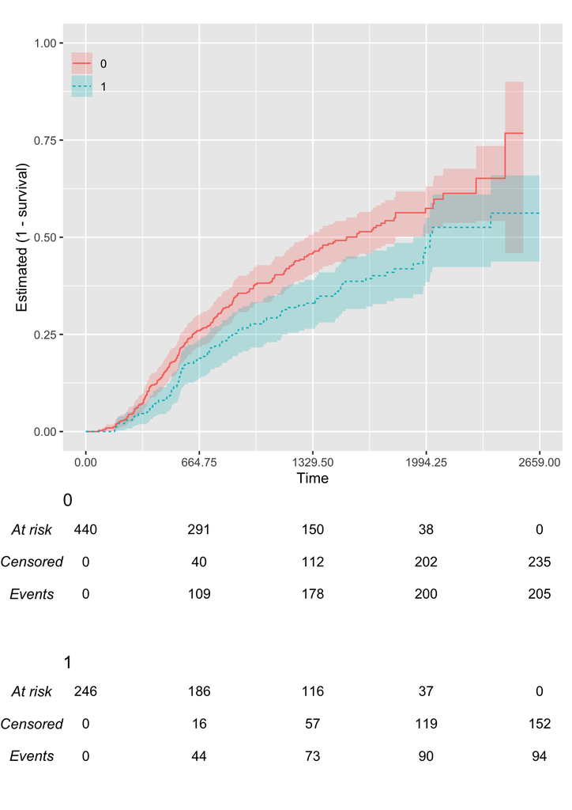

```r
KMunicate(
  fit = fit2,
  time_scale = ts,
  .reverse = TRUE,
  .legend_position = "none"
)
```

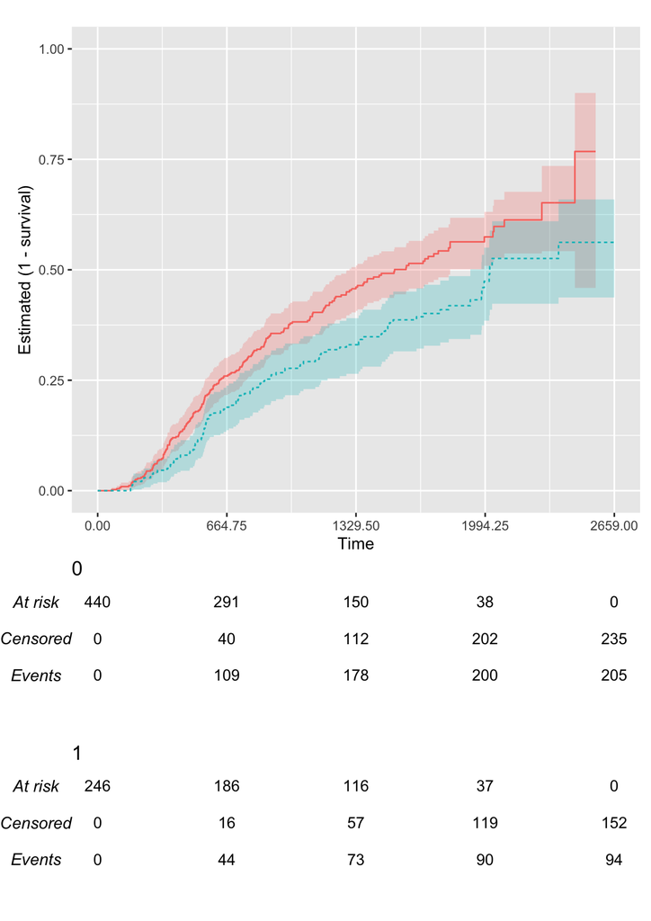

You can add custom annotations via the `.annotate` argument:

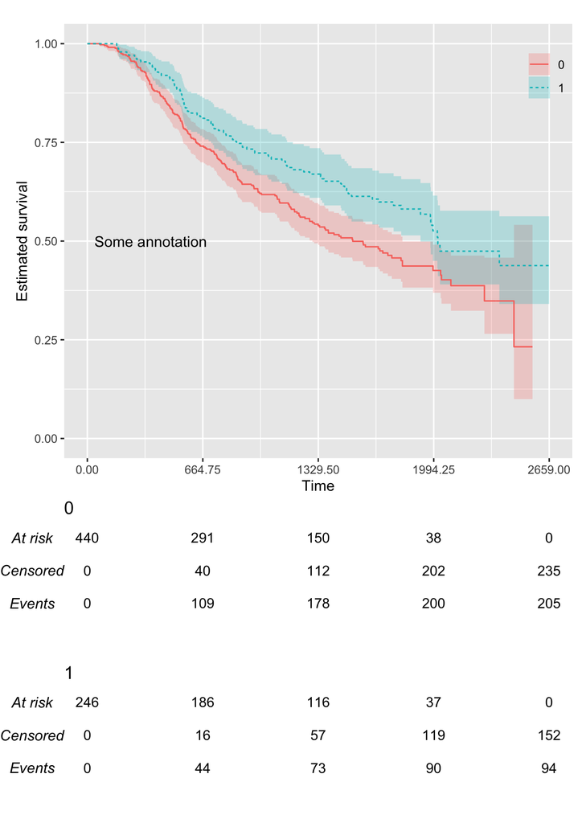

```r
KMunicate(
  fit = fit2,
  time_scale = ts,
  .annotate = ggplot2::annotate(geom = "text", x = 365, y = 0.5, label = "Some annotation")
)
```

You can add customise labels and title with the `.xlab`, `.ylab`, and `.title` arguments:

```r
KMunicate(
  fit = fit2,
  time_scale = ts,
  .xlab = "New Label, X Axis",
  .ylab = "New Label, Y Axis",
  .title = "New Title Who Dis"
)
```

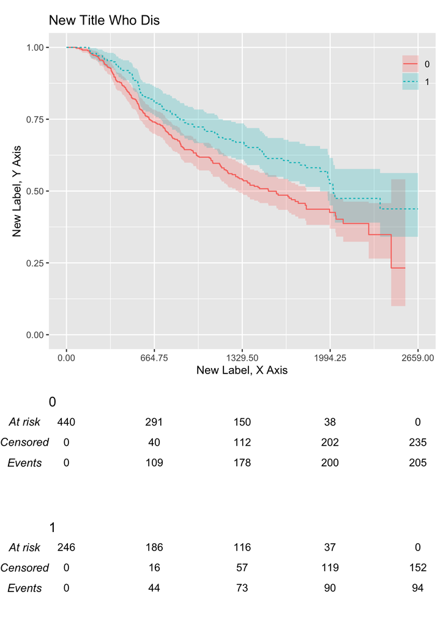